# R: Spectral Indices

| spectralIndices {RStoolbox} | R Documentation |
| --- | --- |

## Spectral Indices

### Description

Calculate a suite of multispectral indices such as NDVI, SAVI etc. in an efficient way.

### Usage

```r
spectralIndices(
  img,
  blue = NULL,
  green = NULL,
  red = NULL,
  nir = NULL,
  redEdge1 = NULL,
  redEdge2 = NULL,
  redEdge3 = NULL,
  swir1 = NULL,
  swir2 = NULL,
  swir3 = NULL,
  scaleFactor = 1,
  skipRefCheck = FALSE,
  indices = NULL,
  index = NULL,
  maskLayer = NULL,
  maskValue = 1,
  coefs = list(L = 0.5, G = 2.5, L_evi = 1, C1 = 6, C2 = 7.5, s = 1, swir2ccc = NULL,
    swir2coc = NULL),
  ...
)
```

### Arguments

[output not shown]

### Details

`spectralIndices` calculates all indices in one go in C++, which is more efficient than calculating each index separately (for large rasters). By default all indices which can be calculated given the specified indices will be calculated. If you don't want all indices, use the `indices` argument to specify exactly which indices are to be calculated. See the table bellow for index names and required bands.

Index values outside the valid value ranges (if such a range exists) will be set to NA. For example a pixel with NDVI > 1 will be set to NA.

| **Index** | **Description** | **Source** | **Bands** | **Formula** |
| --- | --- | --- | --- | --- |
| CLG | Green-band Chlorophyll Index | Gitelson2003 | `redEdge3, green` | `redEdge3/green - 1` |
| CLRE | Red-edge-band Chlorophyll Index | Gitelson2003 | `redEdge3, redEdge1` | `redEdge3/redEdge1 - 1` |
| CTVI | Corrected Transformed Vegetation Index | Perry1984 | `red, nir` | `(NDVI + 0.5)/sqrt(abs(NDVI + 0.5))` |
| DVI | Difference Vegetation Index | Richardson1977 | `red, nir` | `s * nir - red` |
| EVI | Enhanced Vegetation Index | Huete1999 | `red, nir, blue` | `G * ((nir - red)/(nir + C1 * red - C2 * blue + L_evi))` |
| EVI2 | Two-band Enhanced Vegetation Index | Jiang 2008 | `red, nir` | `G * (nir - red)/(nir + 2.4 * red + 1)` |
| GEMI | Global Environmental Monitoring Index | Pinty1992 | `red, nir` | `(((nir^2 - red^2) * 2 + (nir * 1.5) + (red * 0.5))/(nir + red + 0.5)) * (1 - ((((nir^2 - red^2) * 2 + (nir * 1.5) + (red * 0.5))/(nir + red + 0.5)) * 0.25)) - ((red - 0.125)/(1 - red))` |
| GNDVI | Green Normalised Difference Vegetation Index | Gitelson1998 | `green, nir` | `(nir - green)/(nir + green)` |
| KNDVI | Kernel Normalised Difference Vegetation Index | Camps-Valls2021 | `red, nir` | `tanh(((nir - red)/(nir + red)))^2` |
| MCARI | Modified Chlorophyll Absorption Ratio Index | Daughtery2000 | `green, red, redEdge1` | `((redEdge1 - red) - (redEdge1 - green)) * (redEdge1/red)` |
| MNDWI | Modified Normalised Difference Water Index | Xu2006 | `green, swir2` | `(green - swir2)/(green + swir2)` |
| MSAVI | Modified Soil Adjusted Vegetation Index | Qi1994 | `red, nir` | `nir + 0.5 - (0.5 * sqrt((2 * nir + 1)^2 - 8 * (nir - (2 * red))))` |
| MSAVI2 | Modified Soil Adjusted Vegetation Index 2 | Qi1994 | `red, nir` | `(2 * (nir + 1) - sqrt((2 * nir + 1)^2 - 8 * (nir - red)))/2` |
| MTCI | MERIS Terrestrial Chlorophyll Index | DashAndCurran2004 | `red, redEdge1, redEdge2` | `(redEdge2 - redEdge1)/(redEdge1 - red)` |
| NBRI | Normalised Burn Ratio Index | Garcia1991 | `nir, swir3` | `(nir - swir3)/(nir + swir3)` |
| NDREI1 | Normalised Difference Red Edge Index 1 | GitelsonAndMerzlyak1994 | `redEdge2, redEdge1` | `(redEdge2 - redEdge1)/(redEdge2 + redEdge1)` |
| NDREI2 | Normalised Difference Red Edge Index 2 | Barnes2000 | `redEdge3, redEdge1` | `(redEdge3 - redEdge1)/(redEdge3 + redEdge1)` |
| NDVI | Normalised Difference Vegetation Index | Rouse1974 | `red, nir` | `(nir - red)/(nir + red)` |
| NDVIC | Corrected Normalised Difference Vegetation Index | Nemani1993 | `red, nir, swir2` | `(nir - red)/(nir + red) * (1 - ((swir2 - swir2ccc)/(swir2coc - swir2ccc)))` |
| NDWI | Normalised Difference Water Index | McFeeters1996 | `green, nir` | `(green - nir)/(green + nir)` |
| NDWI2 | Normalised Difference Water Index | Gao1996 | `nir, swir2` | `(nir - swir2)/(nir + swir2)` |
| NRVI | Normalised Ratio Vegetation Index | Baret1991 | `red, nir` | `(red/nir - 1)/(red/nir + 1)` |
| REIP | Red Edge Inflection Point | GuyotAndBarnet1988 | `red, redEdge1, redEdge2, redEdge3` | `0.705 + 0.35 * ((red + redEdge3)/(2 - redEdge1))/(redEdge2 - redEdge1)` |
| RVI | Ratio Vegetation Index |  | `red, nir` | `red/nir` |
| SATVI | Soil Adjusted Total Vegetation Index | Marsett2006 | `red, swir2, swir3` | `(swir2 - red)/(swir2 + red + L) * (1 + L) - (swir3/2)` |
| SAVI | Soil Adjusted Vegetation Index | Huete1988 | `red, nir` | `(nir - red) * (1 + L)/(nir + red + L)` |
| SLAVI | Specific Leaf Area Vegetation Index | Lymburger2000 | `red, nir, swir2` | `nir/(red + swir2)` |
| SR | Simple Ratio Vegetation Index | Birth1968 | `red, nir` | `nir/red` |
| TTVI | Thiam's Transformed Vegetation Index | Thiam1997 | `red, nir` | `sqrt(abs((nir - red)/(nir + red) + 0.5))` |
| TVI | Transformed Vegetation Index | Deering1975 | `red, nir` | `sqrt((nir - red)/(nir + red) + 0.5)` |
| WDVI | Weighted Difference Vegetation Index | Richardson1977 | `red, nir` | `nir - s * red` |

Some indices require additional parameters, such as the slope of the soil line which are specified via a list to the `coefs` argument. Although the defaults are sensible values, values like the soil brightnes factor `L` for SAVI should be adapted depending on the characteristics of the scene. The coefficients are:

| **Coefficient** | **Description** | **Affected Indices** |
| --- | --- | --- |
| `s` | slope of the soil line | DVI, WDVI |
| `L_evi, C1, C2, G` | various | EVI |
| `L` | soil brightness factor | SAVI, SATVI |
| `swir2ccc` | minimum swir2 value (completely closed forest canopy) | NDVIC |
| `swir2coc` | maximum swir2 value (completely open canopy) | NDVIC |

| **Band** | **Description** | **Wavl_min** | **Wavl_max** | **Landsat5_Band** | **Sentinel2_Band** |
| --- | --- | --- | --- | --- | --- |
| vis | visible | 400 | 680 | 1,2,3 | 2,3,4 |
| red-edge1 | red-edge1 | 680 | 720 | - | 5 |
| red-edge2 | red-edge2 | 720 | 760 | - | 6 |
| red-edge3 | red-edge3 | 760 | 800 | - | 7 |
| nir | near infra-red | 800 | 1100 | 4 | 8/8a |
| swir1 | short-wave infra-red | 1100 | 1351 | - | 9,10 |
| swir2 | short-wave infra-red | 1400 | 1800 | 5 | 11 |
| swir3 | short-wave infra-red | 2000 | 2500 | 7 | 12 |
| mir1 | mid-wave infra-red | 3000 | 4000 | - | - |
| mir2 | mid-wave infra-red | 45000 | 5000 | - | - |
| tir1 | thermal infra-red | 8000 | 9500 | - | - |
| tir2 | thermal infra-red | 10000 | 140000 | 6 | - |

### Value

SpatRaster

### Examples

```r
library(ggplot2)
library(terra)

## Calculate NDVI
ndvi <- spectralIndices(lsat, red = "B3_dn", nir = "B4_dn", indices = "NDVI")
ndvi
```

```
## class       : SpatRaster
## dimensions  : 310, 287, 1  (nrow, ncol, nlyr)
## resolution  : 30, 30  (x, y)
## extent      : 619395, 628005, -419505, -410205  (xmin, xmax, ymin, ymax)
## coord. ref. : +proj=utm +zone=22 +ellps=WGS84 +towgs84=0,0,0,0,0,0,0 +units=m +no_defs
## source(s)   : memory
## name        :       NDVI
## min value   : -0.5789474
## max value   :  0.7629630
```

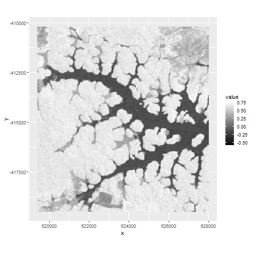

```r
ggR(ndvi, geom_raster = TRUE) +
        scale_fill_gradientn(colours = c("black", "white"))
```

```r
## No test:

## Calculate all possible indices, given the provided bands
## Convert DNs to reflectance (required to calculate EVI and EVI2)
mtlFile  <- system.file("external/landsat/LT52240631988227CUB02_MTL.txt", package="RStoolbox")
lsat_ref <- radCor(lsat, mtlFile, method = "apref")
```

```
## 01:39:38 | Bands to convert to reflectance: B1_dn, B2_dn, B3_dn, B4_dn, B5_dn, B7_dn
```

```
## 01:39:38 | Thermal bands to convert to brightness temperature: B6_dn
```

```
## 01:39:38 | Processing thermal band(s)
```

```
## 01:39:38 | Processing radiance / reflectance
```

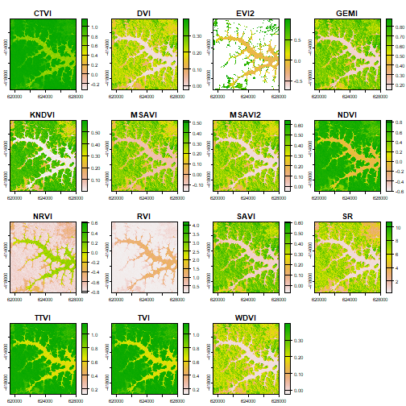

```r
SI <- spectralIndices(lsat_ref, red = "B3_tre", nir = "B4_tre")
plot(SI)
```

```r
## End(No test)
```

[Package *RStoolbox* version 0.4.0 Index]